# Assignment 5

Jatin Jain

**Data 624 - Predictive Analytics**

**Chapter 7**

### 7.1 Consider the pigs series — the number of pigs slaughtered in Victoria each month.

#### a. Use the ses() function in R to find the optimal values of α and ℓ<sub>0</sub>, and generate forecasts for the next four months.

```r
library(fpp2)
help(pigs)
```

```r
fc <- ses(pigs, h=4)
summary(fc)
```

```
##
## Forecast method: Simple exponential smoothing
##
## Model Information:
## Simple exponential smoothing
##
## Call:
##  ses(y = pigs, h = 4)
##
##   Smoothing parameters:
##     alpha = 0.2971
##
##   Initial states:
##     l = 77260.0561
##
##   sigma:  10308.58
##
##      AIC     AICc      BIC
## 4462.955 4463.086 4472.665
##
## Error measures:
##                    ME    RMSE      MAE       MPE     MAPE      MASE       ACF1
## Training set 385.8721 10253.6 7961.383 -0.922652 9.274016 0.7966249 0.01282239
##
## Forecasts:
##          Point Forecast    Lo 80    Hi 80    Lo 95    Hi 95
## Sep 1995       98816.41 85605.43 112027.4 78611.97 119020.8
## Oct 1995       98816.41 85034.52 112598.3 77738.83 119894.0
## Nov 1995       98816.41 84486.34 113146.5 76900.46 120732.4
## Dec 1995       98816.41 83958.37 113674.4 76092.99 121539.8
```

#### So the α is 0.2971 and ℓ<sub>0</sub> is 77260.0561.

#### b. Compute a 95% prediction interval for the first forecast using ^y ± 1.96s where s is the standard deviation of the residuals. Compare your interval with the interval produced by R.

```r
fcpt <- 98816.41
s <- sd(residuals(fc))
paste('Point forecst:', fcpt)
```

```
## [1] "Point forecst: 98816.41"
```

```r
paste('Lo 95:', fcpt - 1.96 * s)
```

```
## [1] "Lo 95: 78679.9711418255"
```

```r
paste('Hi 95', fcpt + 1.96 * s)
```

```
## [1] "Hi 95 118952.848858174"
```

#### It seems the interval calculated by the R is slightly wider than the one calculated by the formula above. The lower 95% interval limit is higher than R’s lower limit, and the upper limit is lower than R’s upper limit. The different is about 68 on both + and - sides.

### 7.5 Data set books contains the daily sales of paperback and hardcover books at the same store. The task is to forecast the next four days’ sales for paperback and hardcover books.

#### a. Plot the series and discuss the main features of the data.

```r
help(books)
```

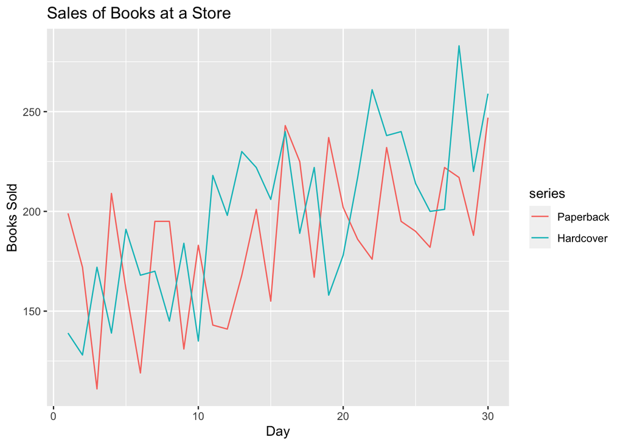

```r
autoplot(books) +
  ggtitle('Sales of Books at a Store') +
  xlab('Day') +
  ylab('Books Sold')
```

#### It appears that both time series (paperback and hardcover) are cyclic and the sales are trending upward. There is no apparent seasonal pattern. Hardcovers sell generally better than paperback.

#### b. Use the ses() function to forecast each series, and plot the forecasts.

```r
sesfitp <- ses(books[,1])
sesfith <- ses(books[,2])
summary(sesfitp)
```

```
##
## Forecast method: Simple exponential smoothing
##
## Model Information:
## Simple exponential smoothing
##
## Call:
##  ses(y = books[, 1])
##
##   Smoothing parameters:
##     alpha = 0.1685
##
##   Initial states:
##     l = 170.8271
##
##   sigma:  34.8183
##
##      AIC     AICc      BIC
## 318.9747 319.8978 323.1783
##
## Error measures:
##                    ME     RMSE     MAE       MPE     MAPE      MASE       ACF1
## Training set 7.175981 33.63769 27.8431 0.4736071 15.57784 0.7021303 -0.2117522
##
## Forecasts:
##    Point Forecast    Lo 80    Hi 80    Lo 95    Hi 95
## 31       207.1097 162.4882 251.7311 138.8670 275.3523
## 32       207.1097 161.8589 252.3604 137.9046 276.3147
## 33       207.1097 161.2382 252.9811 136.9554 277.2639
## 34       207.1097 160.6259 253.5935 136.0188 278.2005
## 35       207.1097 160.0215 254.1979 135.0945 279.1249
## 36       207.1097 159.4247 254.7946 134.1818 280.0375
## 37       207.1097 158.8353 255.3840 133.2804 280.9389
## 38       207.1097 158.2531 255.9663 132.3899 281.8294
## 39       207.1097 157.6777 256.5417 131.5099 282.7094
## 40       207.1097 157.1089 257.1105 130.6400 283.5793
```

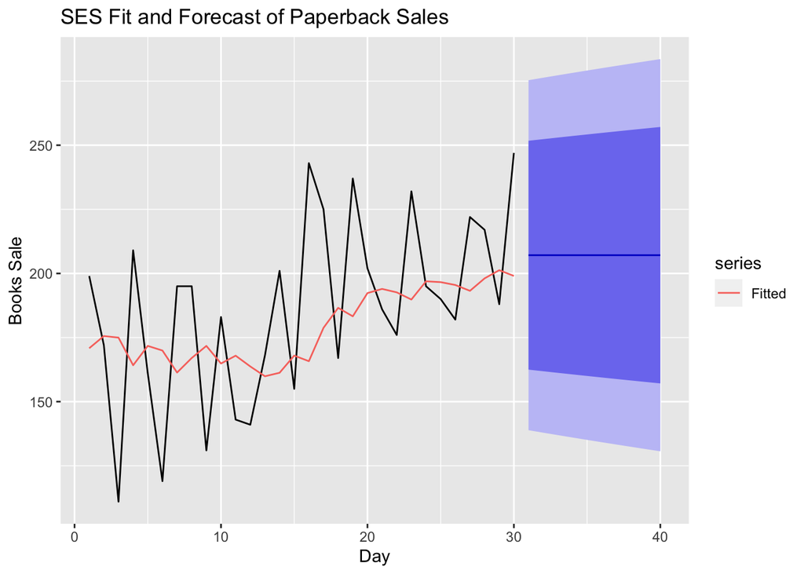

```r
autoplot(sesfitp) +
  autolayer(fitted(sesfitp), series='Fitted') +
  ggtitle('SES Fit and Forecast of Paperback Sales') +
  xlab('Day') +
  ylab('Books Sale')
```

```r
summary(sesfith)
```

```
##
## Forecast method: Simple exponential smoothing
##
## Model Information:
## Simple exponential smoothing
##
## Call:
##  ses(y = books[, 2])
##
##   Smoothing parameters:
##     alpha = 0.3283
##
##   Initial states:
##     l = 149.2861
##
##   sigma:  33.0517
##
##      AIC     AICc      BIC
## 315.8506 316.7737 320.0542
##
## Error measures:
##                    ME     RMSE      MAE      MPE     MAPE      MASE       ACF1
## Training set 9.166735 31.93101 26.77319 2.636189 13.39487 0.7987887 -0.1417763
##
## Forecasts:
##    Point Forecast    Lo 80    Hi 80    Lo 95    Hi 95
## 31       239.5601 197.2026 281.9176 174.7799 304.3403
## 32       239.5601 194.9788 284.1414 171.3788 307.7414
## 33       239.5601 192.8607 286.2595 168.1396 310.9806
## 34       239.5601 190.8347 288.2855 165.0410 314.0792
## 35       239.5601 188.8895 290.2306 162.0662 317.0540
## 36       239.5601 187.0164 292.1038 159.2014 319.9188
## 37       239.5601 185.2077 293.9124 156.4353 322.6848
## 38       239.5601 183.4574 295.6628 153.7584 325.3618
## 39       239.5601 181.7600 297.3602 151.1625 327.9577
## 40       239.5601 180.1111 299.0091 148.6406 330.4795
```

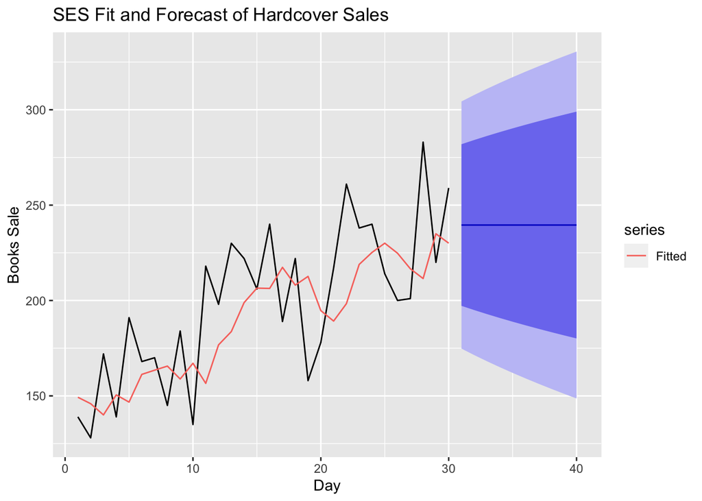

```r
autoplot(sesfith) +
  autolayer(fitted(sesfith), series='Fitted') +
  ggtitle('SES Fit and Forecast of Hardcover Sales') +
  xlab('Day') +
  ylab('Books Sale')
```

#### c. Compute the RMSE values for the training data in each case.

```r
round(accuracy(sesfitp), 2)
```

```
##                ME  RMSE   MAE  MPE  MAPE MASE  ACF1
## Training set 7.18 33.64 27.84 0.47 15.58  0.7 -0.21
```

#### For the paperback time series, the RMSE is 33.64 books.

```r
round(accuracy(sesfith), 2)
```

```
##                ME  RMSE   MAE  MPE  MAPE MASE  ACF1
## Training set 9.17 31.93 26.77 2.64 13.39  0.8 -0.14
```

#### For the hardcover time series, the RMSE is 31.93 books.

### 7.6 We will continue with the daily sales of paperback and hardcover books in data set books.

#### a. Apply Holt’s linear method to the paperback and hardback series and compute four-day forecasts in each case.

#### Paperback forecast using Holt’s linear method:

```r
holtfitp <- holt(books[,1], h=4)
forecast(holtfitp)
```

```
##    Point Forecast    Lo 80    Hi 80    Lo 95    Hi 95
## 31       209.4668 166.6035 252.3301 143.9130 275.0205
## 32       210.7177 167.8544 253.5811 145.1640 276.2715
## 33       211.9687 169.1054 254.8320 146.4149 277.5225
## 34       213.2197 170.3564 256.0830 147.6659 278.7735
```

#### Hardcover forecast using Holt’s linear method:

```r
holtfith <- holt(books[,2], h=4)
forecast(holtfith)
```

```
##    Point Forecast    Lo 80    Hi 80    Lo 95    Hi 95
## 31       250.1739 212.7390 287.6087 192.9222 307.4256
## 32       253.4765 216.0416 290.9113 196.2248 310.7282
## 33       256.7791 219.3442 294.2140 199.5274 314.0308
## 34       260.0817 222.6468 297.5166 202.8300 317.3334
```

#### b. Compare the RMSE measures of Holt’s method for the two series to those of simple exponential smoothing in the previous question. (Remember that Holt’s method is using one more parameter than SES.) Discuss the merits of the two forecasting methods for these data sets.

```r
round(accuracy(holtfitp), 2)
```

```
##                 ME  RMSE   MAE   MPE  MAPE MASE  ACF1
## Training set -3.72 31.14 26.18 -5.51 15.58 0.66 -0.18
```

```r
round(accuracy(holtfith), 2)
```

```
##                 ME  RMSE   MAE   MPE  MAPE MASE  ACF1
## Training set -0.14 27.19 23.16 -2.11 12.16 0.69 -0.03
```

#### * For the paperback time series, the RMSE is 31.14 books. This is 33.64-31.14 = 2.5 improvement.

#### * For the hardcover time series, the RMSE is 27.19 books. This is 31.93-27.19 = 4.74 improvement.

#### * So in terms of prediction accuracy in the training set, Holt’s method is better than the simple exponential smoothing.

#### * Holt’s method takes into account the trend element of a time series, while the SES does not have a trend element.

#### * The books dataset clearly exhibit a upward trend. Therefore, Holt’s method is more appropriate.

#### c. Compare the forecasts for the two series using both methods. Which do you think is best?

```r
sesfitp <- ses(books[,1], h=4)
sesfith <- ses(books[,1], h=4)
```

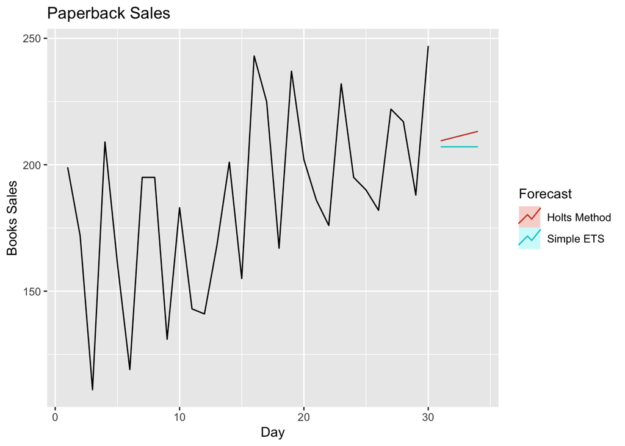

```r
autoplot(books[,1]) +
  autolayer(holtfitp, series='Holts Method', PI=F) +
  autolayer(sesfitp, series='Simple ETS', PI=F) +
  ggtitle('Paperback Sales') +
  xlab('Day') +
  ylab('Books Sales') +
  guides(colour=guide_legend(title="Forecast"))
```

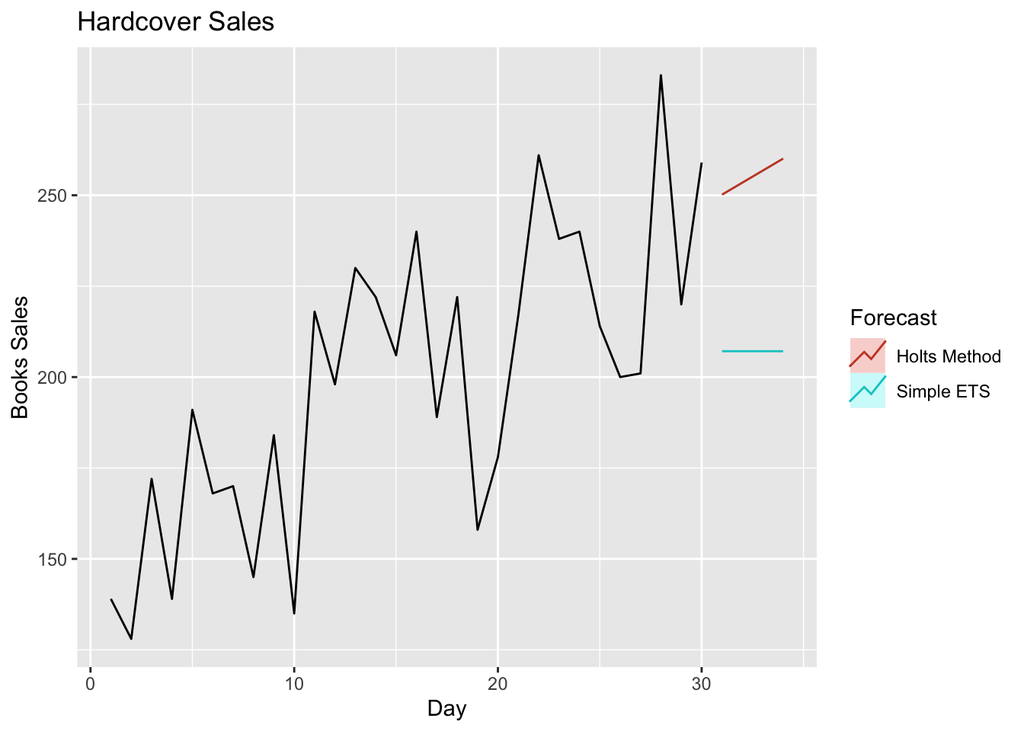

```r
autoplot(books[,2]) +
  autolayer(holtfith, series='Holts Method', PI=F) +
  autolayer(sesfith, series='Simple ETS', PI=F) +
  ggtitle('Hardcover Sales') +
  xlab('Day') +
  ylab('Books Sales') +
  guides(colour=guide_legend(title="Forecast"))
```

#### * I think that the Holt’s method is better, for the reasons explained above.

#### * The simple ETS method will forecast a constant value without taking account trend, while Holt’s method does.

#### d. Calculate a 95% prediction interval for the first forecast for each series, using the RMSE values and assuming normal errors. Compare your intervals with those produced using ses and holt.

#### Below, I constructed a table to show the first forecast results. The “Calculated” column is calculated using point forecast from Holt’s method and +/- 1.96 * RMSE.

```r
rmsep <- 31.14
ptholtp <- 209.4668
ptsesp <- 207.1097
lowerp <- ptholtp - 1.96 * rmsep
upperp <- ptholtp + 1.96 * rmsep
holtlowerp <- 143.9130
holtupperp <- 275.0205
seslowerp <- 138.8670
sesupperp <- 275.3523

rmseh <- 27.19
ptholth <- 250.1739
ptsesh <- 239.5601
lowerh <- ptholth - 1.96 * rmseh
upperh <- ptholth + 1.96 * rmseh
holtlowerh <- 192.9222
holtupperh <- 307.4256
seslowerh <- 174.7799
sesupperh <- 304.3403

df <- data.frame(c(ptholtp, lowerp, upperp), c(ptholtp, holtlowerp, holtupperp), c(ptsesp, seslowerp, sesupperp), c(ptholth, lowerh, upperh), c(ptholth, holtlowerh, holtupperh), c(ptsesh, seslowerh, sesupperh))
df[4,] <- df[3,] - df[2,]
colnames(df) <- c('Calculated', 'R - holt', 'R - ses', 'Calculated', 'R - holt', 'R - ses')
row.names(df) <- c('Point Forecast', 'Lower 95%', 'Upper 95%', 'Interval Range')

library(kableExtra)

kable(df) %>%
  kable_styling(bootstrap_options = c("striped", "hover", "condensed", "responsive")) %>%
  add_header_above(c(' ', 'Paperback Forecast' = 3, 'Hardcover Forecost' = 3))
```

|  | Paperback Forecast Calculated | Paperback Forecast R - holt | Paperback Forecast R - ses | Hardcover Forecost Calculated | Hardcover Forecost R - holt | Hardcover Forecost R - ses |
| --- | --- | --- | --- | --- | --- | --- |
| Point Forecast | 209.4668 | 209.4668 | 207.1097 | 250.1739 | 250.1739 | 239.5601 |
| Lower 95% | 148.4324 | 143.9130 | 138.8670 | 196.8815 | 192.9222 | 174.7799 |
| Upper 95% | 270.5012 | 275.0205 | 275.3523 | 303.4663 | 307.4256 | 304.3403 |
| Interval Range | 122.0688 | 131.1075 | 136.4853 | 106.5848 | 114.5034 | 129.5604 |

#### From the interval range, it appears that the interval calculated using RMSE is slightly narrower than R calculated using holt() and ses().

### 7.7 For this exercise use data set eggs, the price of a dozen eggs in the United States from 1900–1993. Experiment with the various options in the holt() function to see how much the forecasts change with damped trend, or with a Box-Cox transformation. Try to develop an intuition of what each argument is doing to the forecasts.

### [Hint: use h=100 when calling holt() so you can clearly see the differences between the various options when plotting the forecasts.]

### Which model gives the best RMSE?

#### Below, I experimented with the default holt() and the 3 options of the function. The damped=TRUE will use a damped trend. The exponential=TRUE will use an exponential trend. The lambda=“auto” will turn on Box-Cox transformation for the data and I will also use biasadj=TRUE to get the mean forecast (instead of the median).

```r
help(eggs)
```

```r
default <- holt(eggs, h=100)
damped <- holt(eggs, h=100, damped = T)
exponential <- holt(eggs, h=100, exponential = T)
lambda <- holt(eggs, h=100, lambda = 'auto', biasadj = T)
da_ex <- holt(eggs, h=100, exponential = T, damped = T)
da_la <- holt(eggs, h=100, damped = T, lambda = 'auto', biasadj = T)
```

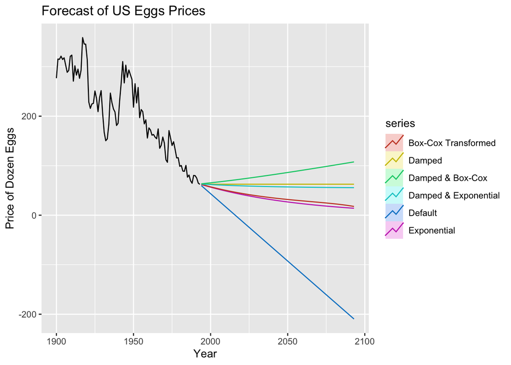

```r
autoplot(eggs) +
  autolayer(default, series='Default', PI=F) +
  autolayer(damped, series='Damped', PI=F) +
  autolayer(exponential, series='Exponential', PI=F) +
  autolayer(lambda, series='Box-Cox Transformed', PI=F) +
  autolayer(da_ex, series='Damped & Exponential', PI=F) +
  autolayer(da_la, series='Damped & Box-Cox', PI=F) +
  ggtitle('Forecast of US Eggs Prices') +
  xlab('Year') +
  ylab('Price of Dozen Eggs')
```

#### * I also tried 2 combination of the options. The damped and exponential options combine will produce a line similar to damped line. It seems the damped effect out-weights the exponential effect. The damped and Box-Cox transformed produces an increase forecast - which clearly does not make sense.

#### * Below are the accuracy for the forecasts:

```r
df <- rbind(accuracy(default), accuracy(damped), accuracy(exponential), accuracy(lambda), accuracy(da_ex), accuracy(da_la))
row.names(df) <- c('Default', 'Damped', 'Exponential', 'Box-Cox', 'Damped & Exponential', 'Damped & Box-Cox')
kable(df) %>%
  kable_styling(bootstrap_options = c("striped", "hover", "condensed", "responsive"))
```

|  | ME | RMSE | MAE | MPE | MAPE | MASE | ACF1 |
| --- | --- | --- | --- | --- | --- | --- | --- |
| Default | 0.0449909 | 26.58219 | 19.18491 | -1.142201 | 9.653791 | 0.9463626 | 0.0134820 |
| Damped | -2.8914955 | 26.54019 | 19.27950 | -2.907633 | 10.018944 | 0.9510287 | -0.0031954 |
| Exponential | 0.4918791 | 26.49795 | 19.29399 | -1.263235 | 9.766049 | 0.9517436 | 0.0103908 |
| Box-Cox | -0.2015298 | 26.38689 | 18.99362 | -1.630430 | 9.713172 | 0.9369265 | 0.0383996 |
| Damped & Exponential | -0.9089678 | 26.59113 | 19.54973 | -2.125756 | 10.023283 | 0.9643590 | 0.0137612 |
| Damped & Box-Cox | -1.8062134 | 26.58589 | 19.55896 | -2.584250 | 10.117605 | 0.9648141 | 0.0053221 |

#### * From the table above, the Box-Cox transformed holt() forecast has the lowest RMSE.

### 7.8 Recall your retail time series data (from Exercise 3 in Section 2.10).

```r
retaildata <- readxl::read_excel("retail.xlsx", skip=1)
```

```r
myts <- ts(retaildata[,"A3349873A"],
  frequency=12, start=c(1982,4))
```

#### a. Why is multiplicative seasonality necessary for this series?

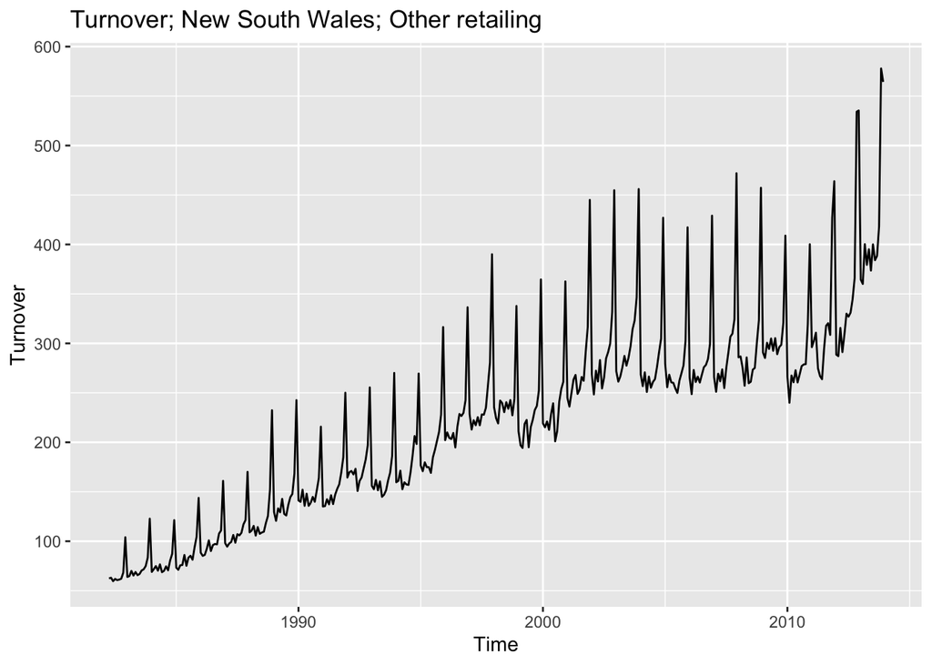

```r
autoplot(myts) +
  ggtitle('Turnover; New South Wales; Other retailing') +
  ylab('Turnover')
```

#### From the plot, it is apparent that the seasonal variation increases porportionally with time. Therefore, multiplicative seasonality is necessary.

#### b. Apply Holt-Winters’ multiplicative method to the data. Experiment with making the trend damped.

#### Holt-Winter’s multiplicative method, with undamped trend:

```r
fit1 <- hw(myts, seasonal='multiplicative', damped=F)
summary(fit1)
```

```
##
## Forecast method: Holt-Winters' multiplicative method
##
## Model Information:
## Holt-Winters' multiplicative method
##
## Call:
##  hw(y = myts, seasonal = "multiplicative", damped = F)
##
##   Smoothing parameters:
##     alpha = 0.504
##     beta  = 1e-04
##     gamma = 0.4578
##
##   Initial states:
##     l = 62.8715
##     b = 0.8152
##     s = 0.9514 0.886 0.9114 1.5529 1.0184 0.9813
##            0.9589 0.9898 0.9593 0.8883 0.9094 0.9929
##
##   sigma:  0.0513
##
##      AIC     AICc      BIC
## 4040.084 4041.770 4107.112
##
## Error measures:
##                     ME     RMSE      MAE        MPE     MAPE      MASE
## Training set 0.1170648 13.29378 8.991856 -0.1217735 3.918351 0.4748948
##                    ACF1
## Training set 0.08635577
##
## Forecasts:
##          Point Forecast    Lo 80    Hi 80    Lo 95    Hi 95
## Jan 2014       390.3784 364.7154 416.0413 351.1303 429.6264
## Feb 2014       391.1995 362.4039 419.9951 347.1605 435.2386
## Mar 2014       427.9732 393.4376 462.5088 375.1555 480.7909
## Apr 2014       394.1500 359.7834 428.5167 341.5908 446.7093
## May 2014       403.4598 365.8492 441.0704 345.9394 460.9802
## Jun 2014       392.3988 353.6036 431.1940 333.0667 451.7309
## Jul 2014       410.9940 368.1710 453.8169 345.5019 476.4860
## Aug 2014       405.6186 361.3056 449.9315 337.8478 473.3893
## Sep 2014       416.5669 369.0509 464.0828 343.8975 489.2362
## Oct 2014       437.9753 385.9982 489.9524 358.4832 517.4674
## Nov 2014       585.8096 513.6953 657.9240 475.5203 696.0990
## Dec 2014       577.7851 504.1964 651.3737 465.2409 690.3292
## Jan 2015       399.6599 342.8992 456.4206 312.8519 486.4679
## Feb 2015       400.4831 342.1250 458.8412 311.2321 489.7341
## Mar 2015       438.1104 372.6939 503.5270 338.0644 538.1564
## Apr 2015       403.4687 341.8115 465.1258 309.1722 497.7652
## May 2015       412.9807 348.4595 477.5019 314.3041 511.6574
## Jun 2015       401.6414 337.5529 465.7300 303.6264 499.6565
## Jul 2015       420.6566 352.1637 489.1496 315.9057 525.4076
## Aug 2015       415.1371 346.2205 484.0538 309.7383 520.5360
## Sep 2015       426.3243 354.2214 498.4272 316.0524 536.5961
## Oct 2015       448.2152 371.0413 525.3891 330.1879 566.2425
## Nov 2015       599.4807 494.4676 704.4937 438.8771 760.0842
## Dec 2015       591.2440 485.9383 696.5497 430.1928 752.2952
```

#### Holt-Winter’s multiplicative method, with damped trend:

```r
fit2 <- hw(myts, seasonal='multiplicative', damped=T)
summary(fit2)
```

```
##
## Forecast method: Damped Holt-Winters' multiplicative method
##
## Model Information:
## Damped Holt-Winters' multiplicative method
##
## Call:
##  hw(y = myts, seasonal = "multiplicative", damped = T)
##
##   Smoothing parameters:
##     alpha = 0.5524
##     beta  = 2e-04
##     gamma = 0.4476
##     phi   = 0.9328
##
##   Initial states:
##     l = 62.9106
##     b = 0.6659
##     s = 0.8986 0.8635 0.8733 1.5546 1.1214 1.0392
##            1.0033 0.9655 0.9238 0.8886 0.9303 0.9378
##
##   sigma:  0.0527
##
##      AIC     AICc      BIC
## 4055.981 4057.871 4126.952
##
## Error measures:
##                    ME     RMSE      MAE       MPE     MAPE      MASE       ACF1
## Training set 1.414869 13.30494 9.042151 0.6105987 3.959617 0.4775511 0.04077895
##
## Forecasts:
##          Point Forecast    Lo 80    Hi 80    Lo 95    Hi 95
## Jan 2014       391.3161 364.8883 417.7439 350.8983 431.7339
## Feb 2014       392.2638 361.9876 422.5401 345.9603 438.5673
## Mar 2014       427.6983 391.0174 464.3792 371.5997 483.7969
## Apr 2014       391.6405 354.9948 428.2863 335.5957 447.6853
## May 2014       399.2265 358.9916 439.4614 337.6925 460.7605
## Jun 2014       387.6109 345.9350 429.2868 323.8731 451.3487
## Jul 2014       405.5421 359.3641 451.7201 334.9189 476.1653
## Aug 2014       399.6910 351.7735 447.6085 326.4076 472.9745
## Sep 2014       410.5242 358.9526 462.0958 331.6522 489.3962
## Oct 2014       430.9373 374.4342 487.4405 344.5233 517.3514
## Nov 2014       574.0409 495.7448 652.3370 454.2974 693.7845
## Dec 2014       564.4915 484.6264 644.3565 442.3484 686.6345
## Jan 2015       391.6898 330.2053 453.1743 297.6574 485.7222
## Feb 2015       392.6313 329.2488 456.0139 295.6961 489.5666
## Mar 2015       428.0919 357.1258 499.0579 319.5587 536.6251
## Apr 2015       391.9948 325.3521 458.6376 290.0736 493.9161
## May 2015       399.5818 329.9960 469.1677 293.1595 506.0042
## Jun 2015       387.9507 318.8208 457.0805 282.2257 493.6756
## Jul 2015       405.8924 331.9582 479.8266 292.8198 518.9650
## Aug 2015       400.0316 325.6130 474.4502 286.2182 513.8450
## Sep 2015       410.8695 332.8718 488.8672 291.5822 530.1567
## Oct 2015       431.2954 347.8100 514.7807 303.6156 558.9752
## Nov 2015       574.5123 461.1985 687.8262 401.2138 747.8109
## Dec 2015       564.9500 451.4869 678.4131 391.4232 738.4768
```

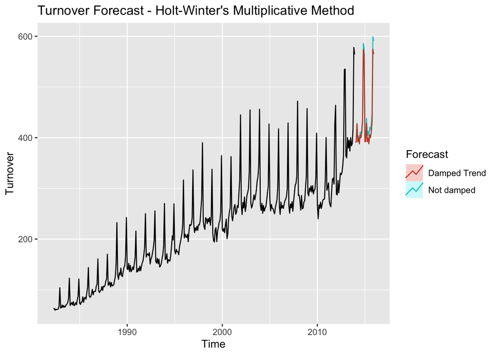

```r
autoplot(myts) +
  autolayer(fit1, PI=F, series='Not damped') +
  autolayer(fit2, PI=F, series='Damped Trend') +
  guides(colour=guide_legend(title="Forecast")) +
  ggtitle("Turnover Forecast - Holt-Winter's Multiplicative Method") +
  ylab('Turnover')
```

#### c. Compare the RMSE of the one-step forecasts from the two methods. Which do you prefer?

#### Accuracy of undamped trend fit:

```r
accuracy(fit1)
```

```
##                     ME     RMSE      MAE        MPE     MAPE      MASE
## Training set 0.1170648 13.29378 8.991856 -0.1217735 3.918351 0.4748948
##                    ACF1
## Training set 0.08635577
```

#### Accuracy of damped trend fit:

```r
accuracy(fit2)
```

```
##                    ME     RMSE      MAE       MPE     MAPE      MASE       ACF1
## Training set 1.414869 13.30494 9.042151 0.6105987 3.959617 0.4775511 0.04077895
```

#### * It seems the undamped trend fit has better RMSE.

#### * I prefer the undamped fit, based on the RMSe and also on the plot above, where it shows that the undamped trend seems to show slight increase prediction that tracks the general increasing trend better than the damped trend.

#### d. Check that the residuals from the best method look like white noise.

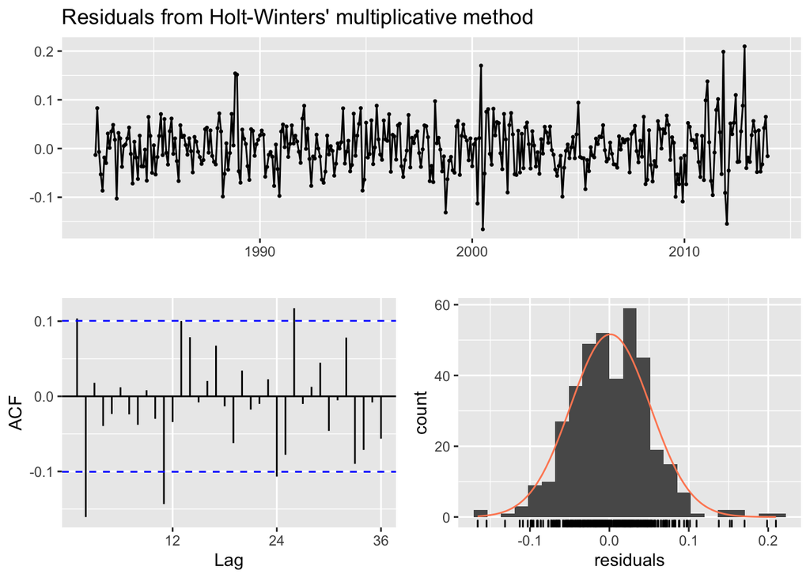

```
##
##  Ljung-Box test
##
## data:  Residuals from Holt-Winters' multiplicative method
## Q* = 40.405, df = 8, p-value = 2.692e-06
##
## Model df: 16.   Total lags used: 24
```

```r
checkresiduals(fit1)
```

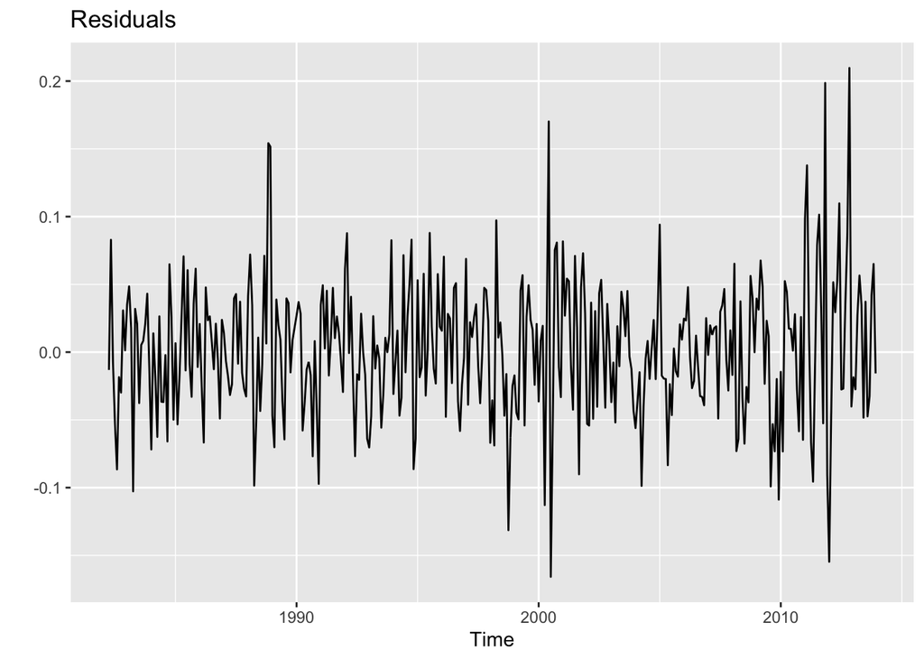

```r
autoplot(residuals(fit1)) +
  ggtitle('Residuals') +
  ylab('')
```

#### e. Now find the test set RMSE, while training the model to the end of 2010. Can you beat the seasonal naïve approach from Exercise 8 in Section 3.7?

#### * Holt-Winter’s Multiplicative Trend (Holt-Winter 1)

#### * Holt-Winter’s Additive Trend, with Box-Cox Transform (Holt-Winter 2)

```r
train <- window(myts, end=c(2010, 12))
test <- window(myts, start=c(2011,1))
```

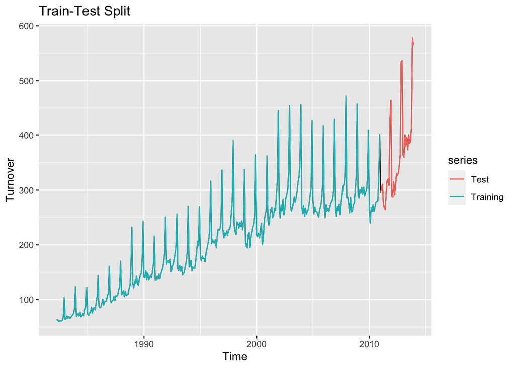

```r
autoplot(myts) +
  autolayer(train, series="Training") +
  autolayer(test, series="Test") +
  ggtitle('Train-Test Split') +
  ylab('Turnover')
```

```r
fit_snaive <- snaive(train, h=36)
fit1_hw <- hw(train, h=36, seasonal='multiplicative', damped=F)
fit2_hw <- hw(train, h=36, seasonal='additive', damped=F, lambda='auto')
```

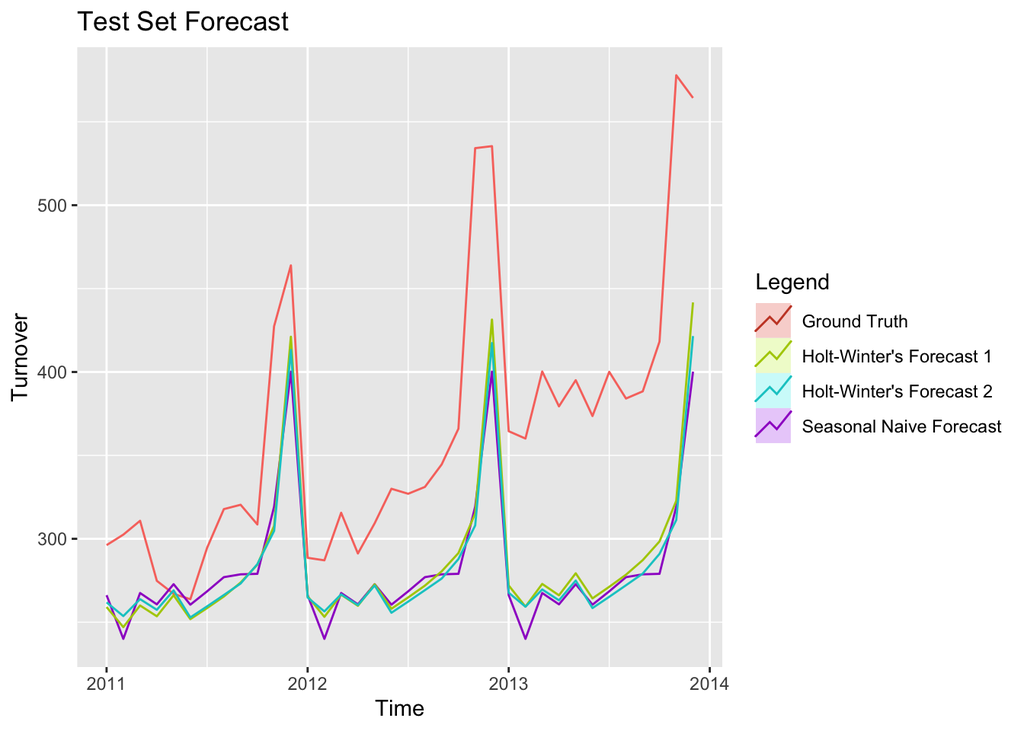

```r
autoplot(test, series='Ground Truth') +
  autolayer(fit_snaive, series='Seasonal Naive Forecast', PI=F) +
  autolayer(fit1_hw, series="Holt-Winter's Forecast 1", PI=F) +
  autolayer(fit2_hw, series="Holt-Winter's Forecast 2", PI=F) +
  guides(colour=guide_legend(title="Legend")) +
  ggtitle('Test Set Forecast') +
  ylab('Turnover')
```

```r
library(Metrics)
df <- c(rmse(test, fit_snaive$mean), rmse(test, fit1_hw$mean), rmse(test, fit2_hw$mean))
names(df) <- c('Seasonal Naive Forecast', "Holt-Winter's Multiplicative Method",
               "Holt-Winter's Additive Method with Box-Cox Transform")
df
```

```
##                              Seasonal Naive Forecast
##                                            100.00869
##                  Holt-Winter's Multiplicative Method
##                                             94.80662
## Holt-Winter's Additive Method with Box-Cox Transform
##                                             99.21057
```

#### Therefore the Holt-Winter’s Multiplicative method, with no damping trend, beats the seasonal naive forecast slightly.

### 7.9 For the same retail data, try an STL decomposition applied to the Box-Cox transformed series, followed by ETS on the seasonally adjusted data. How does that compare with your best previous forecasts on the test set?

#### Below, the training set is first Box-Cox transformed, and then decomposed using STL.

```r
train <- ts(as.vector(myts), start=c(1982,4), end=c(2010,12), frequency = 12)
lambda <- BoxCox.lambda(train)
paste('Best lambda for Box-Cox Transformation is found to be:', lambda)
```

```
## [1] "Best lambda for Box-Cox Transformation is found to be: 0.197968156308491"
```

```r
train.bc <- BoxCox(train, lambda)
fit.stl <- stl(train.bc, s.window='periodic', robust=T)
```

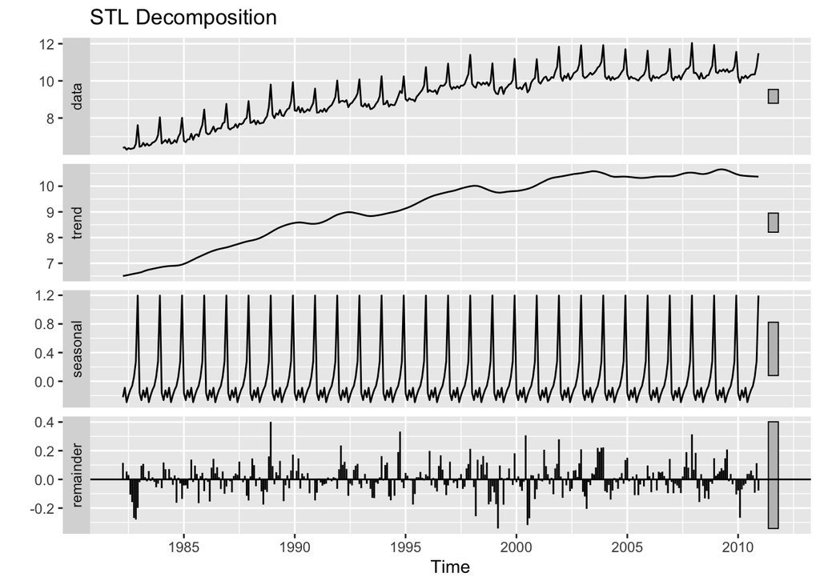

```r
autoplot(fit.stl) +
  ggtitle('STL Decomposition')
```

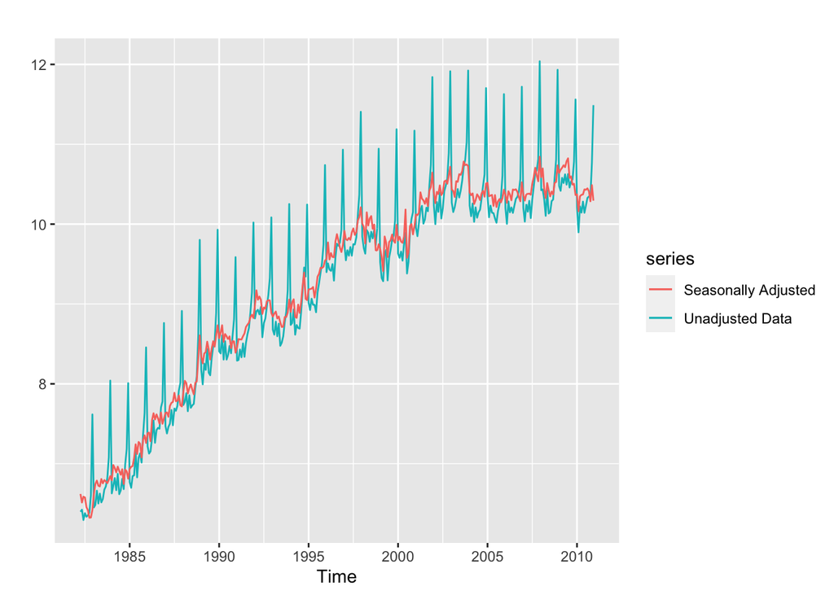

```r
train.bc.seadj <- train.bc - fit.stl$time.series[,'seasonal']

autoplot(train.bc, series='Unadjusted Data') +
  autolayer(train.bc.seadj, series='Seasonally Adjusted') +
  ylab('')
```

#### Next, I fit the seasonally adjusted data using ETS, and let ETS automatically search for best fit:

```r
fit.ets <- ets(train.bc.seadj)
summary(fit.ets)
```

```
## ETS(M,A,N)
##
## Call:
##  ets(y = train.bc.seadj)
##
##   Smoothing parameters:
##     alpha = 0.6333
##     beta  = 1e-04
##
##   Initial states:
##     l = 6.567
##     b = 0.0134
##
##   sigma:  0.0129
##
##      AIC     AICc      BIC
## 543.5141 543.6911 562.7319
##
## Training set error measures:
##                        ME      RMSE       MAE         MPE      MAPE      MASE
## Training set -0.003878286 0.1172707 0.0899321 -0.03866332 0.9882063 0.3832231
##                    ACF1
## Training set 0.01864534
```

#### The function found ETS(M,A,N), with multiplicative error, additive trend, and no seasonal component. I then use this to make a forecast on the test set. The forecast is then back transformed using InvBoxCox().

```r
fc1 <- forecast(fit.ets, h=36)$mean
fc1 <- InvBoxCox(fc1, lambda=lambda)
fc1
```

```
##           Jan      Feb      Mar      Apr      May      Jun      Jul      Aug
## 2011 280.4265 281.6456 282.8690 284.0966 285.3286 286.5648 287.8053 289.0500
## 2012 295.3390 296.6098 297.8850 299.1647 300.4487 301.7371 303.0300 304.3273
## 2013 310.8809 312.2051 313.5338 314.8670 316.2048 317.5472 318.8941 320.2456
##           Sep      Oct      Nov      Dec
## 2011 290.2992 291.5526 292.8104 294.0725
## 2012 305.6291 306.9353 308.2460 309.5612
## 2013 321.6016 322.9623 324.3276 325.6975
```

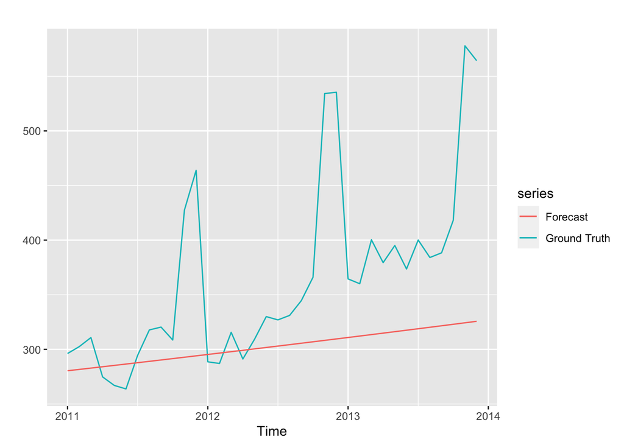

```r
autoplot(test, series='Ground Truth') +
  autolayer(fc1, series='Forecast') +
  ylab('')
```

#### Since there is no seasonal component, the forecast is a straight line trend. The RMSE is found to be:

```r
rmse(test, fc1)
```

```
## [1] 96.15759
```

#### This cannot beat the best previous forecast, which has test set RMSE of 94.807.